# info/noninfo prior

2023-09-21

# Use informative/noninformative for the fatal accidents data

- Informative priors: provides strong information.
- Noninfomative priors: No informative included, let the data speak for themselves
- Weakly informative priors: The information it does provide is intentionally weaker than whatever actual prior knowledge is available.

Prior Recommendation(after normalization):

- Flat prior (not usually recommended);
- Super-vague but proper prior: normal(0, 1e6) (not usually recommended);
- Weakly informative prior, very weak: normal(0, 10);
- Generic weakly informative prior: normal(0, 1);
- Specific informative prior: normal(0.4, 0.2) or whatever. Sometimes this can be expressed as a scaling followed by a generic prior: theta = 0.4 + 0.2*z; z ~ normal(0, 1);

For example, in a simple linear regression, y and x are normalized, based on 2$\sigma$ rule, there is around 95% that y changes with in (-2,2) if x changes 1, so $\beta \sim N(0,1)$ can provide some information of $\beta$ but it is not quite strong compared to informative priors.

Statements such as “informative” or “weakly informative” depend crucially on what questions are being asked (a point that is related to the idea that the prior can often only be understood in the context of the likelihood

A principle to construct weak informative prior: write down what you think the prior should be, then spread it out. The idea is that the cost of setting the prior too narrow is more severe than the cost of setting it too wide.

Two ways to construct weakly informative prior:

1. Start with some version of a noninformative prior distribution and then add enough information so that inferences are constrained to be reasonable.
2. Start with a strong, highly informative prior and broaden it to account for uncertainty in one’s prior beliefs and in the applicability of any historically based prior distribution to new data

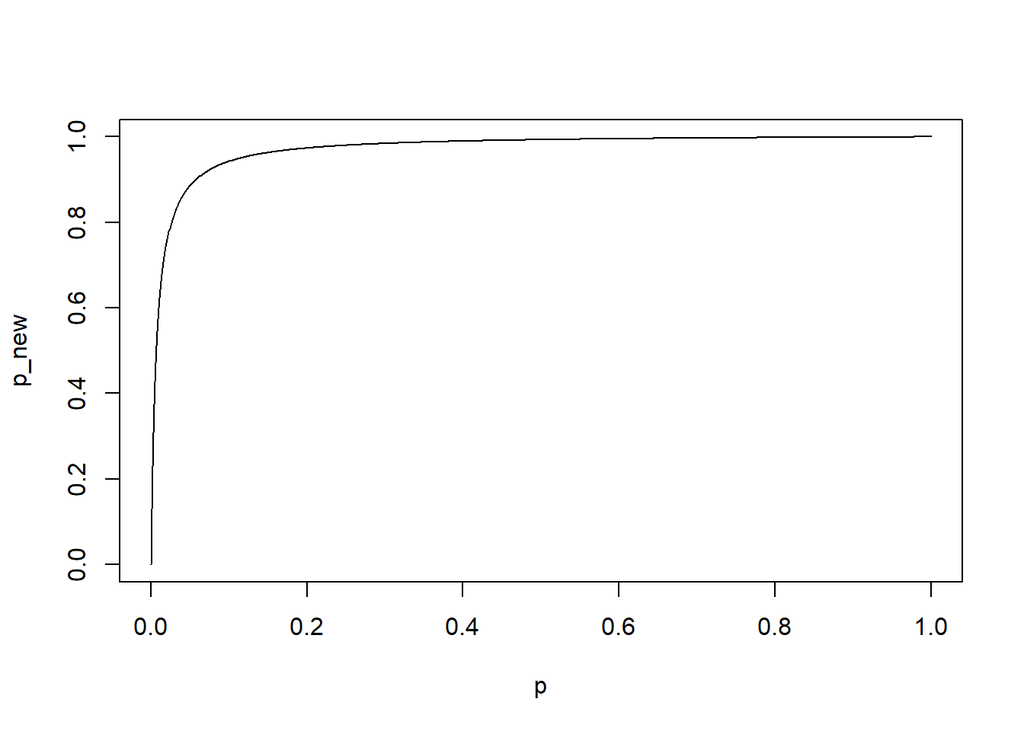

```r
logistic_prob <- function(coef,p){
  1/(1+exp(-coef)*(1-p)/p)
}

p <- seq(0,1,length.out=1000)
p_new <- logistic_prob(5, p)
plot(p,p_new, type="line")
```

For logistic regression, a change of 5 moves a probability from 0.01 to 0.5, or from 0.5 to 0.99

## Model

Model Specification We model the number of fatal accidentsY as a Poisson random variable:
$$Y \sim
\text{Poisson}(\lambda)$$
where
$$\lambda=a+b*t$$
, t is time variable, the very first year in the dataset is set to be t=0.

Choices of priors:

- noninformative: unbounded flat prior, diffuse prior
  $$N(0,1000)$$
- weaklyinformative: half Cauchy prior
  $$Cauchy(0,10)$$
  ,and
  $$Cauchy(0,2.5)$$
- informative:
  $$a\sim N(30,5)$$
  ,
  $$b \sim N(1,1.5)$$

```r
library("rstan")
library(dplyr)
library(ggplot2)
library(MASS)
library(DT)
library(gridExtra)

url_to_rda <- "https://github.com/ucincy-grad-bayesian-group/meeting/raw/main/week5/BDAdata.rda"
# Open a connection to the URL
con <- url(url_to_rda)
# Load the .rda file into R
load(con)
# Close the connection
close(con)

set.seed(1234)
BDAdata$t <- BDAdata$year - min(BDAdata$year)
```

Stan Models

```r
stan_flat ="
data {
    int<lower=0> N;            // Number of observations
    vector[N] t;            // time data
    int<lower=0> fatal_accidents[N]; // Observed fatal accidents
}

parameters {
    real a;        // Intercept
    real b;        // Slope
}

model {
    vector[N] lambda;
    for (i in 1:N) {
        lambda[i] = a + b * t[i];
    }
    fatal_accidents ~ poisson(lambda);
}
"

stan_HalfCauchy="
data {
    int<lower=0> N;
    vector[N] t;
    int<lower=0> fatal_accidents[N];
}

parameters {
    real<lower=0> a;
    real b;
}

model {
    vector[N] lambda;
    a ~ cauchy(0, 10);
    b ~ cauchy(0, 2.5);
    for (i in 1:N) {
        lambda[i] = a + b * t[i];
    }
    fatal_accidents ~ poisson(lambda);
}
"

stan_NormalDiffuse="
data {
    int<lower=0> N;
    vector[N] t;
    int<lower=0> fatal_accidents[N];
}

parameters {
    real a;
    real b;
}

model {
    vector[N] lambda;
    a ~ normal(0, 1000);
    b ~ normal(0, 1000);
    for (i in 1:N) {
        lambda[i] = a + b * t[i];
    }
    fatal_accidents ~ poisson(lambda);
}

"

stan_infoNormal="
data {
    int<lower=0> N;
    vector[N] t;
    int<lower=0> fatal_accidents[N];
}

parameters {
    real a;
    real b;
}

model {
    vector[N] lambda;

    // Informative priors
    a ~ normal(30, 5);
    b ~ normal(1, 1.5);

    for (i in 1:N) {
        lambda[i] = a + b * t[i];
    }

    fatal_accidents ~ poisson(lambda);
}

"
```

```r
stan_data <- list(
  N = length(BDAdata$t),
  t = BDAdata$t,
  fatal_accidents = BDAdata$Fatalaccidents
)
```

```r
samples_flat <- rstan::extract(fit_flat, permuted = TRUE)
samples_halfcauchy <- rstan::extract(fit_HalfCauchy, permuted = TRUE)
samples_diffusenormal <- rstan::extract(fit_NormalDiffuse, permuted = TRUE)
samples_infonormal <- rstan::extract(fit_infoNormal, permuted = TRUE)
```

```r
summarize_samples <- function(samples) {
  list(
    mean_a = round(mean(samples$a),2),
    sd_a = round(sd(samples$a),2),
    q025_a = round(quantile(samples$a, 0.025),2),
    q975_a = round(quantile(samples$a, 0.975),2),
    mean_b = round(mean(samples$b),2),
    sd_b = round(sd(samples$b),2),
    q025_b = round(quantile(samples$b, 0.025),2),
    q975_b = round(quantile(samples$b, 0.975),2)
  )
}

summary_flat <- summarize_samples(samples_flat)
summary_halfcauchy <- summarize_samples(samples_halfcauchy)
summary_diffusenormal <- summarize_samples(samples_diffusenormal)
summary_infonormal <- summarize_samples(samples_infonormal)

summary_df <- data.frame(
  rbind(
    cbind(Prior = "Flat", t(summary_flat)),
    cbind(Prior = "Cauchy", t(summary_halfcauchy)),
    cbind(Prior = "Normal", t(summary_diffusenormal)),
    cbind(Prior = "Other", t(summary_infonormal))
  )
)

datatable(summary_df, caption = "Summary Statistics Table")
```

|  | Prior | mean_a | sd_a | q025_a | q975_a | mean_b | sd_b | q025_b | q975_b |
| --- | --- | --- | --- | --- | --- | --- | --- | --- | --- |
| 1 | ['Flat'] | [28.1] | [3.02] | [22.27] | [34.26] | [-0.91] | [0.54] | [-1.94] | [0.15] |
| 2 | ['Cauchy'] | [27.32] | [3.04] | [21.49] | [33.39] | [-0.78] | [0.55] | [-1.85] | [0.29] |
| 3 | ['Normal'] | [28.27] | [3.04] | [22.58] | [34.48] | [-0.94] | [0.54] | [-2.02] | [0.16] |
| 4 | ['Other'] | [27.92] | [2.58] | [23.03] | [33.33] | [-0.84] | [0.47] | [-1.78] | [0.1] |

generate prior samples

```r
a_halfcauchy <- rcauchy(10000,0,10)
b_halfcauchy <- rcauchy(10000,0,2.5)
prior_sample_hc <- data.frame(a=a_halfcauchy,b=b_halfcauchy)

a_diffuse <- rnorm(40000,0,1000)
b_diffuse <- rnorm(40000,0,1000)
prior_sample_diffuse <- data.frame(a=a_diffuse,b=b_diffuse)

a_info <- rnorm(40000,30,5)
b_info <- rnorm(40000,1,1.5)
prior_sample_info <- data.frame(a=a_info,b=b_info)
```

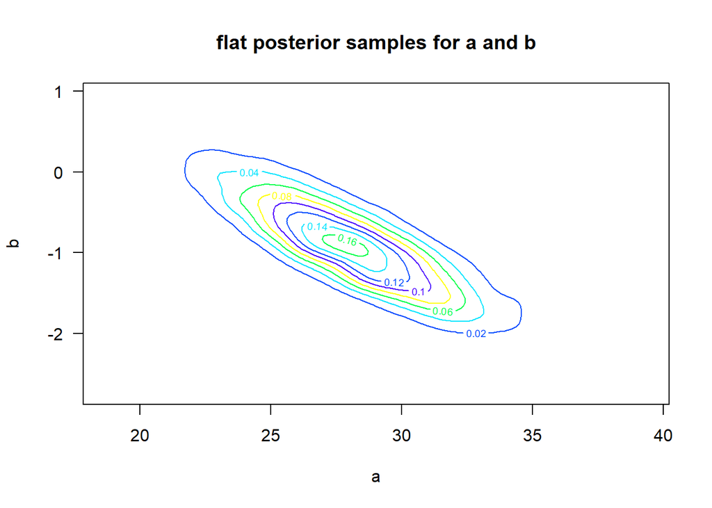

```r
density_flat_post <- kde2d(samples_flat$a,samples_flat$b,n=100)
contour(density_flat_post, main = "flat posterior samples for a and b",
         xlab = "a", ylab = "b", las = 1, col = topo.colors(5))
```

Contour plots of prior vs posterior:Half Cauchy

[figure not shown]

```r
density_hc_prior <- kde2d(prior_sample_hc$a, prior_sample_hc$b, n = 100)  # 'n' controls the grid size
density_hc_post <- kde2d(samples_halfcauchy$a,samples_halfcauchy$b,n=100)
par(mfrow=c(1,2))
contour(density_hc_prior, main = "Half Cauchy prior samples for a and b",
         xlab = "a", ylab = "b", las = 1, col = topo.colors(5),xlim = c(-1000,1000),ylim = c(-1000,1000) )
contour(density_hc_post, main = "Half Cauchy posterior samples for a and b",
         xlab = "a", ylab = "b", las = 1, col = topo.colors(5))
```

Contour plots of prior vs posterior:Diffuse

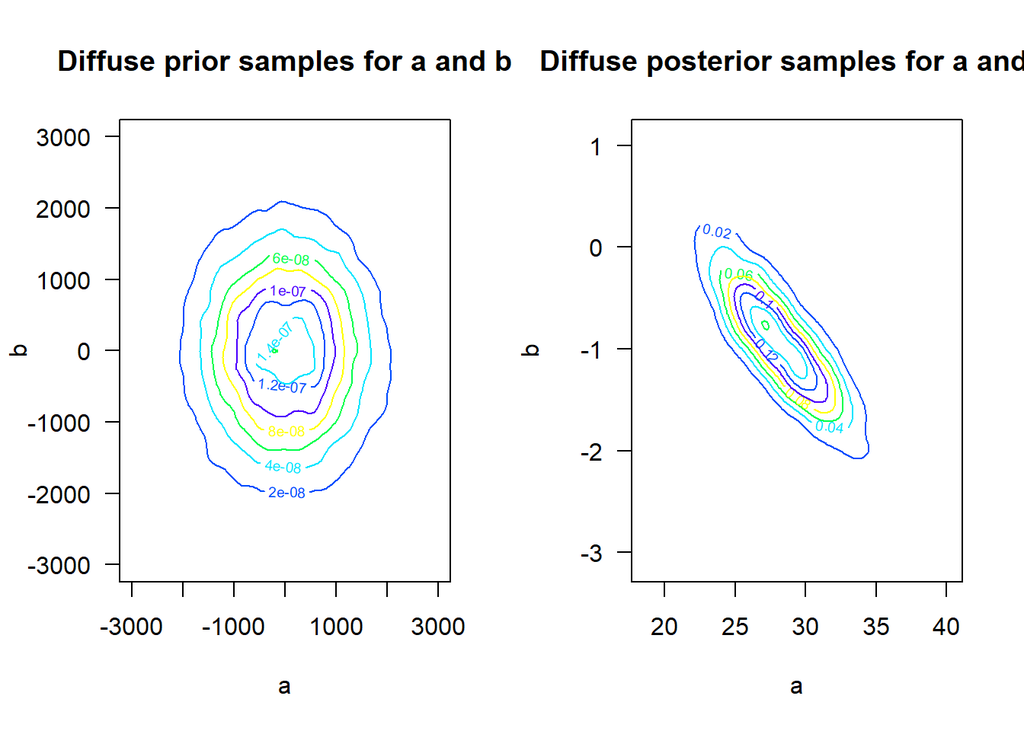

```r
density_diffuse_prior <- kde2d(prior_sample_diffuse$a, prior_sample_diffuse$b, n = 100)  # 'n' controls the grid size
density_diffuse_post <- kde2d(samples_diffusenormal$a,samples_diffusenormal$b,n=100)
par(mfrow=c(1,2))
contour(density_diffuse_prior, main = "Diffuse prior samples for a and b",
         xlab = "a", ylab = "b", las = 1, col = topo.colors(5),xlim = c(-3000,3000),ylim = c(-3000,3000) )
contour(density_diffuse_post, main = "Diffuse posterior samples for a and b",
         xlab = "a", ylab = "b", las = 1, col = topo.colors(5))
```

Contour plots of prior vs posterior:informative

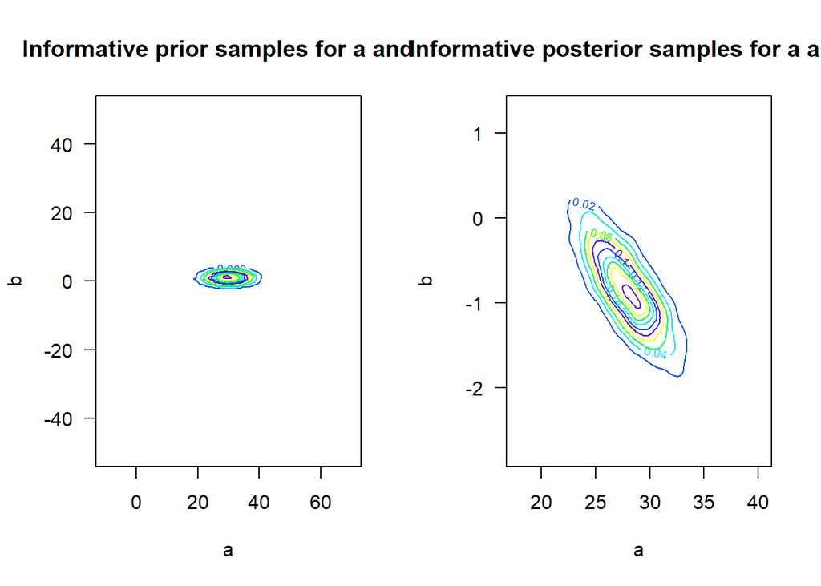

```r
density_info_prior <- kde2d(prior_sample_info$a, prior_sample_info$b, n = 100)  # 'n' controls the grid size
density_info_post <- kde2d(samples_infonormal$a,samples_infonormal$b,n=100)
par(mfrow=c(1,2))
contour(density_info_prior, main = "Informative prior samples for a and b",
         xlab = "a", ylab = "b", las = 1, col = topo.colors(5),xlim = c(-10,70),ylim = c(-50,50) )
contour(density_info_post, main = "Informative posterior samples for a and b",
         xlab = "a", ylab = "b", las = 1, col = topo.colors(5))
```

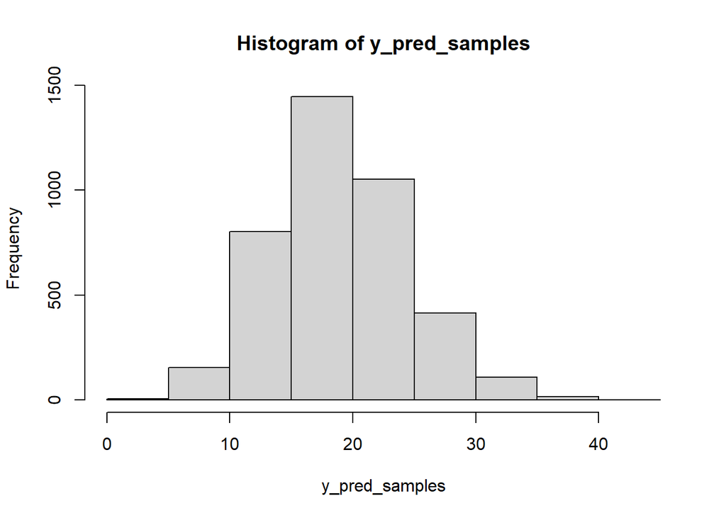

```r
# Simulated posterior samples for illustration

a_samples <- samples_halfcauchy$a
b_samples <- samples_halfcauchy$b

# Assuming t is a scalar
t <- 10  # For example

# If t is a vector, then the simulation will produce predictive samples for each value of t
# t <- c(1,2,3,4,5)  # For example

# Calculate lambda for all samples
lambda_samples <- a_samples + b_samples * t

# Draw from Poisson distribution
y_pred_samples <- rpois(4000, lambda_samples)

h <- hist(y_pred_samples)
```

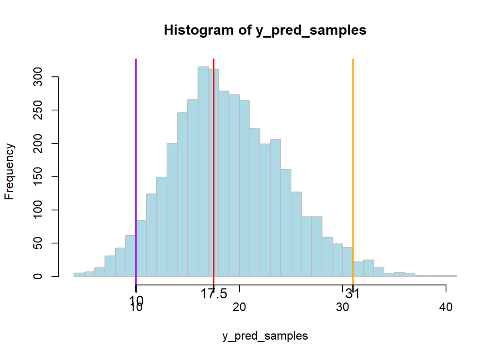

```r
max_bin_index <- which.max(h$counts)
x_max <- h$mids[max_bin_index]
q2_5 <- quantile(y_pred_samples, 0.025)
q97_5 <- quantile(y_pred_samples, 0.975)
plot.new()
hist(y_pred_samples, border="gray", col="lightblue",nclass=50)
abline(v=c(x_max, q2_5, q97_5), col=c("red", "purple", "orange"), lwd=2)
axis(1, at=c(x_max, q2_5, q97_5), labels=round(c(x_max, q2_5, q97_5), 2), lwd.ticks=2, cex.axis=1.2, padj=c(-0.5, -1.2, -1.2))
```

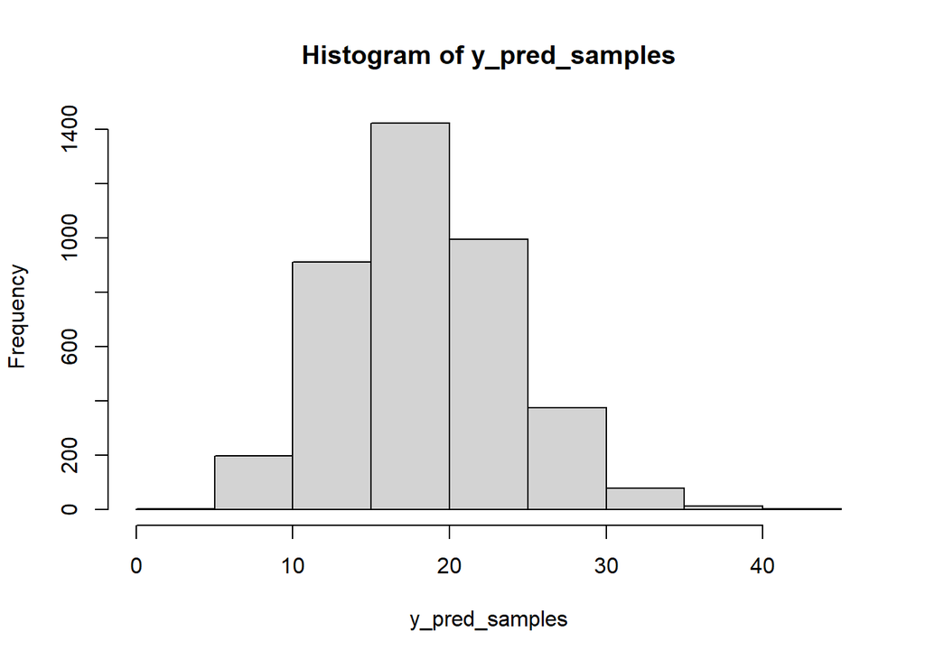

```r
# Simulated posterior samples for illustration

a_samples <- samples_diffusenormal$a
b_samples <- samples_diffusenormal$b

# Assuming t is a scalar
t <- 10  # For example

# If t is a vector, then the simulation will produce predictive samples for each value of t
# t <- c(1,2,3,4,5)  # For example

# Calculate lambda for all samples
lambda_samples <- a_samples + b_samples * t

# Draw from Poisson distribution
y_pred_samples <- rpois(4000, lambda_samples)

h <- hist(y_pred_samples)
```

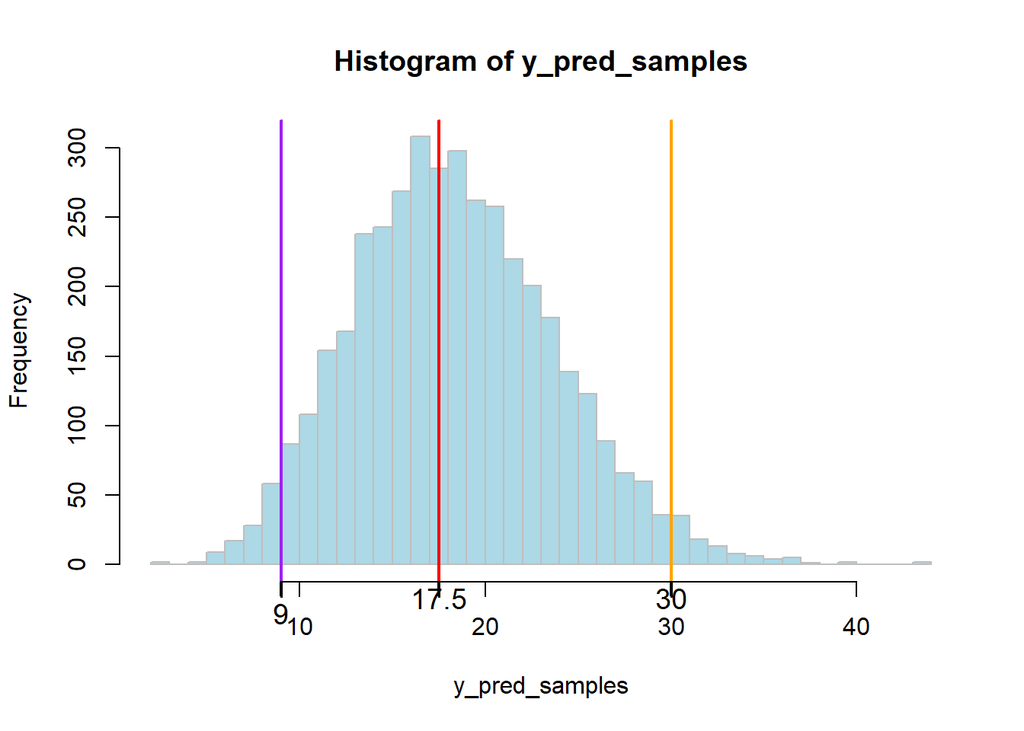

```r
max_bin_index <- which.max(h$counts)
x_max <- h$mids[max_bin_index]
q2_5 <- quantile(y_pred_samples, 0.025)
q97_5 <- quantile(y_pred_samples, 0.975)
plot.new()
hist(y_pred_samples, border="gray", col="lightblue",nclass=50)
abline(v=c(x_max, q2_5, q97_5), col=c("red", "purple", "orange"), lwd=2)
axis(1, at=c(x_max, q2_5, q97_5), labels=round(c(x_max, q2_5, q97_5), 2), lwd.ticks=2, cex.axis=1.2, padj=c(-0.5, -1.2, -1.2))
```

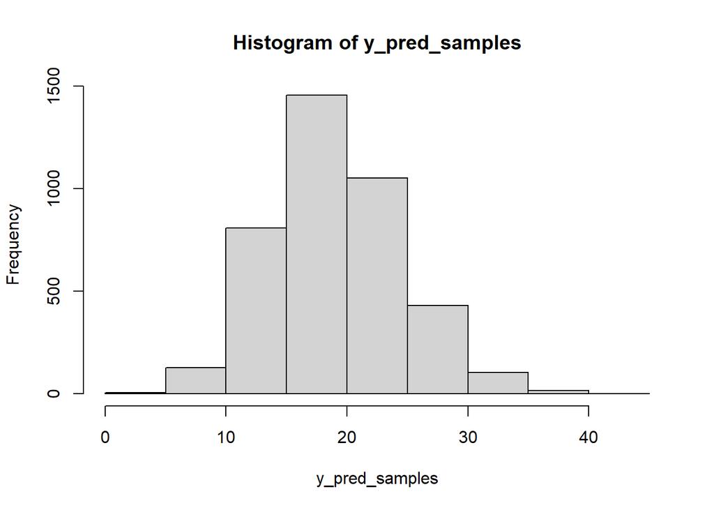

```r
# Simulated posterior samples for illustration

a_samples <- samples_infonormal$a
b_samples <- samples_infonormal$b

# Assuming t is a scalar
t <- 10  # For example

# If t is a vector, then the simulation will produce predictive samples for each value of t
# t <- c(1,2,3,4,5)  # For example

# Calculate lambda for all samples
lambda_samples <- a_samples + b_samples * t

# Draw from Poisson distribution
y_pred_samples <- rpois(4000, lambda_samples)

h <- hist(y_pred_samples)
```

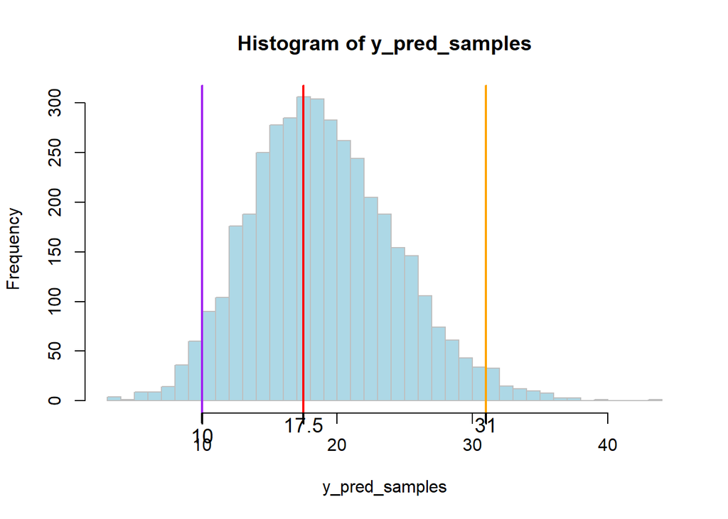

```r
max_bin_index <- which.max(h$counts)
x_max <- h$mids[max_bin_index]
q2_5 <- quantile(y_pred_samples, 0.025)
q97_5 <- quantile(y_pred_samples, 0.975)
plot.new()
hist(y_pred_samples, border="gray", col="lightblue",nclass=50)
abline(v=c(x_max, q2_5, q97_5), col=c("red", "purple", "orange"), lwd=2)
axis(1, at=c(x_max, q2_5, q97_5), labels=round(c(x_max, q2_5, q97_5), 2), lwd.ticks=2, cex.axis=1.2, padj=c(-0.5, -1.2, -1.2))
```